[figure not shown]

# Разработка метода продолжения решений посредством автоматического дифференцирования

Малышев Сергей

Февраль 25, 2021

## Почему возникла эта работа?

В предыдущих работах докладчика для изучения поведения динамических систем применялся метод продолжения по параметру. В данном докладе планируется изложить иной подход для реализации этого метода, который, обладает некоторыми преимуществами по сравнению с существующими.

## Содержание

Данный доклад состоит из следующий логических разделов:

1. Введение в автоматическое дифференцирование.
2. Задача продолжения по параметру.
3. Примеры с алгебраической системой и осциллятор Дуффинга.

## Автоматическое дифференцирование

- Автоматическое дифференцирование (АД) - способ вычисления производной заданной алгоритмом.
- АД использует тот факт, что каждая компьютерная программа, выполняет последовательность элементарных арифметических операций (сложение, умножение…) и элементарных функций (exp, cos…).
- АД отличается от символьного и численного дифф-ия (МКР). Символьное дифф-ие может привести к неэффективному коду и столкнуться с трудностями преобразования компьютерной программы в одно выражение, тогда как МКР может привести к ошибкам округления .

## Основы, основы, и еще раз основы

Вспомним некоторые фундаментальные понятия.

Дифференцирование сложной функции.

- Рассмотрим следующею сложную функцию.
  $$y = f(g(h(x))) = f(g(h(w_0))) = f(g(w_1)) = f(w_2) = w_3$$
  - сложная функция
- Производную такой функции можно вычислить по формуле:
  $$\frac{dy}{dx} = \frac{dy}{dw_2} \frac{dw_2}{dw_1} \frac{dw_1}{dx} = \frac{df(w_2)}{dw_2} \frac{dg(w_1)}{dw_1} \frac{dh(w_0)}{dx}$$

## Подходы к реализации АД

Существует два принципиально разных подхода к реализации автоматического дифференцирования.

- Прямой - сначала мы вычисляем $\frac{dw_1}{dx}$ затем $\frac{dw_2}{dw_1}$ и так далее.
- Обратный - сначала мы вычисляем $\frac{dy}{dw_2}$ затем $\frac{dw_2}{dw_1}$ и так далее.

Поскольку в настоящей работе используется прямой метод, на нем остановимся подробнее. Обратный метод предлагается освоить слушателю самостоятельно.

## Разбор прямого метода

- Прямой - сначала мы вычисляем $\frac{dw_1}{dx}$ затем $\frac{dw_2}{dw_1}$ и так далее.
- Обратный - сначала мы вычисляем $\frac{dy}{dw_2}$ затем $\frac{dw_2}{dw_1}$ и так далее.

Поскольку в настоящей работе используется прямой метод, на нем остановимся подробнее. Обратный метод предлагается освоить слушателю самостоятельно.

## Дерево выражений

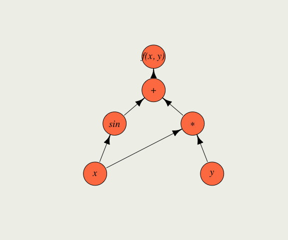

## Вычисление производной

[output not shown]

## Дуальное число

Прямой метод можно реализовать при помощи дуальных чисел.

Дуальное число - это гиперкомплексное число вида
$$a + \varepsilon b,$$

где $a, b \in \mathbb{R}$, a $\varepsilon^2 = 0$.

Над дуальными числами определенны операции сложения и произведения:
$$(a_1 + \varepsilon b_1) + (a_2 + \varepsilon b_2) = (a_1 + a_2) + \varepsilon(b_1 + b_2)$$
$$(a_1 + \varepsilon b_1) (a_2 + \varepsilon b_2) = (a_1 a_2) + \varepsilon(a_1 b_2 + b_1 a_2)$$

## Погружаемся глубже в поле дуальных чисел

Производная частного:
$$(\frac{u}{v})' = \frac{u' v - v' u} {v^2}$$

## Реализация прямого метода с помощью дуальных чисел

Применим дуальные числа для реализации автоматического дифференцирования. Запишем дуальное число в следующем виде.
$$u = u + \varepsilon u',$$
где $u'$ - производная $u$.

Перегрузив операции сложения, произведения, и т.д, а так же приняв $u' = 1$ для интересующей независимой переменной вычислим значение функции $f: D -> D$ используя дуальные числа.

$$f(x_0) = y_0 + \varepsilon y_0',$$

где $y_0' = \frac{df}{dx}|_{x = x_0}$

## Продолжение решений

Сформулируем задачу продолжения решений.

Дано:

Система уравнений $F(x, \lambda) = 0$ где $F: \mathbb{R}^n \rightarrow \mathbb{R}^n, n > 0$, $\lambda \in \mathbb{R}$ - параметр.

Необходимо:

Найти решения системы $F(x, \lambda) = 0$ при различных значениях параметра $\lambda$

## Алгоритм продолжения решений

> *Выбираем начальные значения $x$ и $\lambda$*

> *Фиксируем $\lambda$ и корректируем $x$*

> *Задаем новое значение $\lambda$ и выбираем $x$ для следующего шага*

> *Переходим на первый шаг, или завершаем итерации если это необходимо*

## Продолжение периодических решений

Дана следующая динамическая система.

$$\dot{q} = \theta(q, t, \lambda)$$

где $q \in \mathbb{R}^m, \theta(q, t) = \theta(q, t + T)$ - $T$ -периодическая функция по явно входящему времени, $\lambda$ - некоторый характеристический параметр.

Если исследуются колебания с периодом $T$, то краевые условия (условия периодичности) имеют вид:

$$q(0) = q(T)$$

## 2-х точечная краевая задача

Рассмотрим задачу Коши для системы $\dot{q} = \theta(q, t, \lambda)$ с начальными условиями $q(0) = q_0$ Решение задачи в точке $T$ обозначим как $q(T) = q_T$ и подставляя обозначения в краевые условия $q(0) = q(t)$ получим следующею систему нелинейных уравнений:

$$F(q_0, \lambda) = q_{T} - q_0 = 0$$

## Метод Ньютона

Для системы уравнений $F(x) = 0$ где $F: \mathbb{R}^n \rightarrow \mathbb{R}^n, n > 0$ метод Ньютона можно записать следующим образом.

```r
x - 'initial guess'
tolerance - 'computition tolerance'

while norm(F(x)) < tolerance
  jacobian = jacobian(F, x)
  value = F(x)
  x = x - inverse(jacobian) * value;
```

## Вычисление матрицы Якоби

Для решения задачи продолжения решений необходимо вычислить матрицу Якоби для системы уравнений $F(q_0, \lambda) = q_{T} - q_0 = 0$.

Существует два подхода к вычислению матрицы Якоби:

1. Решение уравнений в вариациях для $\dot{q} = \theta(q, t, \lambda)$.
2. Аппроксимация методом конечных разностей.

|  | Ур-ия в вариациях | МКР |
| --- | --- | --- |
| Символьное дифференцирование | ✅ | ❌ |
| Потеря точности | ❌ | ✅ |

Применяя автоматическое дифференцирование к методу продолжения решений мы будем вычислять матрицу Якоби вместе с системой уравнений.

## Подробнее про дифференцирование метода продолжения решений

1. В программе необходимо заменить все типы с плавающей запятой на дуальные числа.
2. Заменить алгоритм вычисления матрицы Якоби на алгоритм который учитывает АД.
3. Использовать полученный код для вычислений.

## Алгебраическая система из Matcont

$$\begin{cases} a_{11}u_0 + a_{12}u_1 + \alpha e^{u_0} = 0 \\\\ a_{21}u_0 + a_{22}u_1 + \alpha e^{u_1} = 0 \end{cases}$$

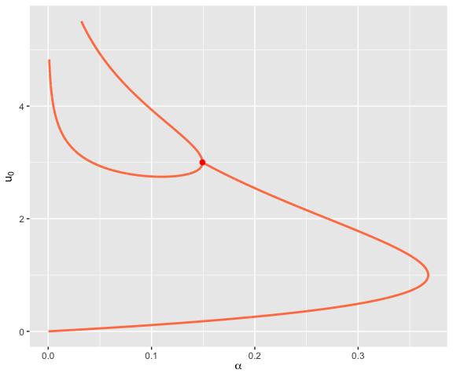

## Пример из Matcont до АД

```cpp
#include <nld/autocont.hpp>
using namespace nld;

vector_xdd f(const vector_xdd& u, dual_d alpha) {
  vector_xdd f(u.size());
  f[0] = - 2 * u[0] + u[1] + a * exp(u[0]);
  f[1] = u[0] - 2 * u[1] + a * exp(u[1]);
  return f;
}

// How to get rid of them?
vector_xdd dfdu(const vector_xdd& u, dual_d a) { // code omitted }
vector_xdd dfda(const vector_xdd& u, dual_d a) { // code omitted }

int main() {
  continuation_parameters params(newton_parameters(10, 0.000001),
    1.45, 0.0002, 0.008, direction::forward);
  vector_xdd u0 = vector_xdd::Zero(2);
  dual_d a0 = 0.0;

  for (auto [p, v] : arc_length(f, dfdu, dfda, params, u0, a0, to_2d<0>)) {
    // Do something with 'p' and 'v';
  }
}
```

## Пример из Matcont после АД

```cpp
#include <nld/autocont.hpp>
using namespace nld;

vector_xdd f(const vector_xdd& u, dual_d alpha) {
  vector_xdd f(u.size());
  f[0] = - 2 * u[0] + u[1] + alpha * exp(u[0]);
  f[1] = u[0] - 2 * u[1] + alpha * exp(u[1]);
  return f;
}

int main() {
  continuation_parameters params(newton_parameters(10, 0.000001),
    1.45, 0.0002, 0.008, direction::forward);
  vector_xdd u0 = vector_xdd::Zero(2);
  dual_d a0 = 0.0;

  for (auto [p, v] : arc_length(f, params, u0, alpha0, to_2d<0>)) {
    // Do something with 'p' and 'v';
  }
}
```

## Осциллятор Дуффинга

$$\ddot{x} + \delta \dot{x} + \alpha x + \beta x^3 = \gamma \cos (\omega t)$$

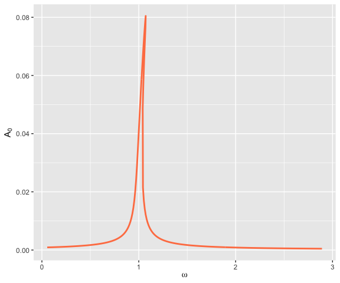

## Периодические решения до АД

```cpp
#include <nld/autocont.hpp>
using namespace nld;

vector_xdd duff(vector_xdd& y, dual_d t, dual_d w) {
  vector_xdd dy(y.size());
  dy[0] = y[1] / w;
  dy[1] = -0.01*y[1] - 0.1*y[0] - 15*y[0]*y[0]*y[0] - 0.86e-3*cos(t);
  return dy;
}

vector_xdd dduffdy(vector_xdd& u, dual_d t, dual_d w) { /* omitted */ }
vector_xdd dduffdw(vector_xdd& u, dual_d t, dual_d w) { /* omitted */ }

int main() {
  // Inittialization omitted
  auto f = two_point_boundary_value_problem<runge_kutta_4>(
    duff, dduffdy, dduffdw, ip);
  //         ^        ^
  for (auto [p, v] : arc_length(f, cp, x, w, half_swing(duff, ip, 0))) {
    // Do something with 'p' and 'v';
  }
}
```

## Периодические решения после АД

```cpp
#include <nld/autocont.hpp>
using namespace nld;

vector_xdd duff(vector_xdd& y, dual_d t, dual_d w) {
  vector_xdd dy(y.size());
  dy[0] = y[1] / w;
  dy[1] = -0.01*y[1] - 0.1*y[0] - 15*y[0]*y[0]*y[0] - 0.86e-3*cos(t);
  return dy;
}

int main() {
  vector_xdd x = vector_xdd::Zero(2);
  dual_d w = 0.05;
  newton_parameters np(10, 0.00005);
  continuation_parameters cp(np, 1.5, 0.0025, 0.001, direction::forward);
  auto ip = constant_step_parameters{ 0.0, 2.0*PI, 200 };
  auto f = two_point_boundary_value_problem<runge_kutta_4>(duff, ip);

  for (auto [p, v] : arc_length(f, cp, x, w, half_swing(duff, ip, 0))) {
    // Do something with 'p' and 'v';
  }
}
```

## Планы

Результатом проделанной работы является библиотека на языке С++ (пока не выпущена) для решения задач нелинейной динамики.

Описанный выше подход к реализации метода продолжения решений будет применен для задачи колебаний шарнирно опертого стержня с трещиной при геометрически нелинейном деформировании.

## Публикации

1. [Periodic, quasi-periodic, and chaotic geometrically nonlinear forced vibrations of a shallow cantilever shell. KV Avramov, SE Malyshev](https://link.springer.com/article/10.1007/s00707-017-2087-x)
2. [Bifurcations and chaotic forced vibrations of cantilever beams with breathing cracks. K Avramov, S Malyshev](https://link.springer.com/article/10.1007/s00707-017-2087-x)
3. [Периодические, почти периодические и хаотические вынужденные колебания пологой консольной оболочки при геометрически нелинейном деформировании С. Е. Малышев, К. В. Аврамов, В. Н. Конкин](http://www.irbis-nbuv.gov.ua/cgi-bin/irbis_nbuv/cgiirbis_64.exe?I21DBN=LINK&P21DBN=UJRN&Z21ID=&S21REF=10&S21CNR=20&S21STN=1&S21FMT=ASP_meta&C21COM=S&2_S21P03=FILA=&2_S21STR=PMash_2017_20_3_6)